# #evol_communes_Europe Quelques données sur les évolutions des mailles communales (ou équivalentes) dans certains pays européens

G. Bideau

23 septembre 2024 15:14:38

NB : Ce script est un document de travail.

Il présente la mise en graphique de données issues de sources secondaires. Le but est d’avoir une vision synthétique de l’évolution du nombre de communes (ou entités équivalentes) dans plusieurs pays européens.

L’ensemble est mis à disposition dans une logique de science ouverte.

Ce travail s’inscrit dans le cadre d’une étude plus générale sur les communes nouvelles :

https://cv.hal.science/gabriel-bideau

Licence CC-BY-NC-SA.

Il est possible d’accéder au code de ce Markdown ici : https://gbideau.github.io/Evol_communes_Europe/evol_Europe.Rmd (le code n’est pas affiché dans ce fichier html pour faciliter la lecture) et au fichier regroupant les données (et les métadonnées) là : https://gbideau.github.io/Evol_communes_Europe/niveau_communal_europe.xlsx.

Ne pas hésiter à contacter l’auteur (gabriel.bideau@gmail.com) pour toute question.

# 1 Objectif

À partir de différentes sources, réalisation d’un tableau donnant l’évolution du niveau communal pour différents pays européens.

# 2 Sources des données

## 2.1 Source des données 1950, 2007 et Appellation1

Comité européen sur la démocratie locale et régionale (CDLR) et Nogueira López Alba, 2007, Les relations entre les autorités centrales et les collectivités locales, s.l., Conseil de l’Europe. Quand plusieurs niveaux étaient disponibles, on a choisi ceux pour lesquels des données étaient disponibles dans les autres sources. https://rm.coe.int/16807480b3

NB : Les données “1950” sont parfois à une autre date, cf. source initiale.

## 2.2 Source des données 2001 et Appellation2

Motte Claude et Vouloir Marie-Christine, 2008, « Frontières administratives et identités communales. Le cas de la France, XVIII-XXe siècles », The Historical Review/La Revue Historique, 2008, vol. 5, p. 213‑238.

## 2.3 Source des données 2012, 2016 et Appellation3

Conseil des Communes et Régions d’Europe, 2016, Gouvernements locaux et régionaux en Europe. Structures et compétences, s.l., CCRE. https://www.ccre.org/img/uploads/piecesjointe/filename/CEMR_structures_and_competences_2016_FR.pdf

## 2.4 Notes

La colonne Comparaison_prbl signale une comparaison problématique : pour la France la prise en compte ou non de l’outre-mer, pour l’Irlande, l’existence de niveaux variés, pour le Royaume-Uni, la comparaison de niveaux différents (et de périmètres différents, tout le Royaume-Uni pour le CCRE), pour la Turquie la comparaison de niveaux visiblement différents.

Compilation réalisée par Gabriel Bideau Date de création : 10/05/2024

# 3 Réalisation d’un tableau et d’un graphique

```r
# Import des données

comm_europe <- read_excel("data-raw/niveau_communal_europe.xlsx",
    col_types = c("text", "text", "text", "text", "numeric", "numeric", "numeric", "numeric", "numeric", "text"))

summary(comm_europe)
```

```
##      Pays           Appellation1       Appellation2       Appellation3
##  Length:26          Length:26          Length:26          Length:26
##  Class :character   Class :character   Class :character   Class :character
##  Mode  :character   Mode  :character   Mode  :character   Mode  :character
##
##
##
##
##       1950            2001            2007              2012
##  Min.   :   77   Min.   :  118   Min.   :   60.0   Min.   :   60
##  1st Qu.:  303   1st Qu.:  308   1st Qu.:  214.2   1st Qu.:  226
##  Median : 1118   Median :  589   Median :  423.5   Median :  430
##  Mean   : 5172   Mean   : 5570   Mean   : 3947.6   Mean   : 4919
##  3rd Qu.: 3427   3rd Qu.: 8089   3rd Qu.: 3206.8   3rd Qu.: 3177
##  Max.   :38000   Max.   :36565   Max.   :36783.0   Max.   :37336
##  NA's   :5       NA's   :13      NA's   :4         NA's   :1
##       2016         Comparaisons_prbl
##  Min.   :   60.0   Length:26
##  1st Qu.:  226.0   Class :character
##  Median :  404.5   Mode  :character
##  Mean   : 4032.8
##  3rd Qu.: 3117.2
##  Max.   :36658.0
##
```

```r
pr_utilis <- subset(comm_europe, is.na(comm_europe$Comparaisons_prbl))
pr_utilis$Pays_appell <- paste0 (pr_utilis$Pays, " (", pr_utilis$Appellation3, ")")
pr_utilis <- pr_utilis[, c(11, 5:9)]
summary(pr_utilis)
```

```
##  Pays_appell             1950            2001              2007
##  Length:22          Min.   :   87   Min.   :  118.0   Min.   :   60.0
##  Class :character   1st Qu.:  303   1st Qu.:  303.2   1st Qu.:  214.2
##  Mode  :character   Median : 1391   Median :  546.5   Median :  423.5
##                     Mean   : 4047   Mean   : 2986.9   Mean   : 2584.6
##                     3rd Qu.: 3427   3rd Qu.: 3791.5   3rd Qu.: 3121.2
##                     Max.   :24156   Max.   :13862.0   Max.   :12340.0
##                     NA's   :5       NA's   :10        NA's   :4
##       2012            2016
##  Min.   :   60   Min.   :   60.0
##  1st Qu.:  226   1st Qu.:  226.0
##  Median :  418   Median :  357.5
##  Mean   : 2306   Mean   : 2179.8
##  3rd Qu.: 2930   3rd Qu.: 2784.5
##  Max.   :11481   Max.   :11313.0
##  NA's   :1
```

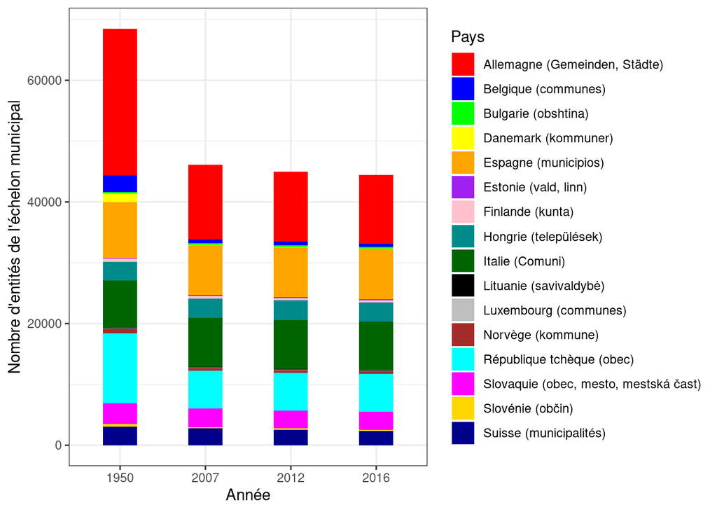

```r
pr_utilis <- pr_utilis[, c(1, 2, 4, 5, 6)]
pr_utilis <- na.omit(pr_utilis)

# pr_plot <- melt(comm_europe[, c(11, 5:9)])
pr_plot <- melt(pr_utilis)

# pr_plot$variable <- as.numeric(as.character(pr_plot$variable))

barplot <- ggplot(pr_plot, aes(x=variable, y=value, fill = Pays_appell)) +
geom_bar( stat = "identity", position =  "stack", width=0.4) +
# scale_fill_brewer(palette="Paired") +
scale_fill_manual(name = "Pays", values=c("red", "blue", "green", "yellow", "orange", "purple", "pink", "darkcyan", "darkgreen", "black", "gray", "brown", "cyan", "magenta", "gold", "darkblue")) +
  ylab("Nombre d'entités de l'échelon municipal") +
  xlab("Année") +
theme_bw()
barplot
```

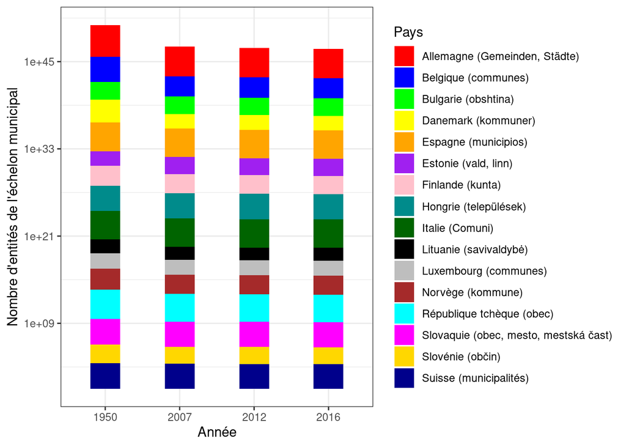

```r
barplot + scale_y_continuous(trans = 'log10')
```

```r
tableau <- subset(comm_europe, is.na(comm_europe$Comparaisons_prbl))
tableau <- tableau [, c(1, 4:9)]

kable(tableau)
```

| Pays | Appellation3 | 1950 | 2001 | 2007 | 2012 | 2016 |
| --- | --- | --- | --- | --- | --- | --- |
| Allemagne | Gemeinden, Städte | 24156 | 13862 | 12340 | 11481 | 11313 |
| Autriche | Gemeinden | NA | 2359 | NA | 2357 | 2100 |
| Belgique | communes | 2669 | 589 | 589 | 589 | 589 |
| Bulgarie | obshtina | 291 | NA | 264 | 264 | 265 |
| Danemark | kommuner | 1391 | 273 | 98 | 98 | 98 |
| Espagne | municipios | 9214 | 8089 | 8111 | 8169 | 8176 |
| Estonie | vald, linn | 96 | NA | 227 | 226 | 213 |
| Finlande | kunta | 547 | 452 | 416 | 336 | 313 |
| Grèce | dimoi | NA | 900 | NA | 325 | 325 |
| Hongrie | települések | 3032 | NA | 3152 | 3177 | 3177 |
| Italie | Comuni | 7781 | 8100 | 8101 | 8094 | 8006 |
| Lituanie | savivaldybė | 87 | NA | 60 | 60 | 60 |
| Luxembourg | communes | 126 | 118 | 116 | 106 | 105 |
| Malte | kunsill lokali | NA | NA | 68 | 68 | 68 |
| Norvège | kommune | 744 | NA | 431 | 430 | 428 |
| Pays-Bas | gemeenten | NA | 504 | NA | 418 | 390 |
| Portugal | municípios | 303 | 308 | 308 | NA | 308 |
| République tchèque | obec | 11459 | NA | 6244 | 6250 | 6258 |
| Slovaquie | obec, mesto, mestská čast | 3427 | NA | 3029 | 2930 | 2938 |
| Slovénie | občin | 371 | NA | 210 | 211 | 212 |
| Suède | kommuner | NA | 289 | NA | 290 | 290 |
| Suisse | municipalités | 3101 | NA | 2758 | 2551 | 2324 |